# Using Meta’s Prophet Forecasting System on Air Passengers Data

## **Using `prophet` For Forecasting**

We will assign the variable `Prophet_Data` to be the one which contains all the information given to us from the `prophet` instruction onto our `dataframe`.

```r
Prophet_Data<- prophet(AirPassengers_DataFrame, daily.seasonality = FALSE, weekly.seasonality = FALSE)
```

As we are focused on monthly figures of air transporters, we will choose to ignore weekly and daily seasonality.

The `prophet` instruction computes many things from the `dataframe`, such as the number of change points in the dates, a seasonality parameter, and can accurately predict whether data given is: linear, logistic or flat. We will be using these thing exactly to make predictions on future figures.

## **Creating & Plotting Future Predictions**

With the newly created `Prophet_Data` we are now ready to make future predictions. We will create these for 24 time periods (months) ahead, using the `make_future_dataframe` instruction, as seen below.

```r
Future_Data<- make_future_dataframe(Prophet_Data,24, freq="month")
Data_Prediction<- predict(Prophet_Data,Future_Data)
tail(Data_Prediction[c('ds','yhat','yhat_lower','yhat_upper')],n=24)
```

```
##             ds     yhat yhat_lower yhat_upper
## 145 1961-01-01 466.1962   439.1271   494.1106
## 146 1961-02-01 460.6461   431.7066   488.4513
## 147 1961-03-01 493.1297   465.4861   521.3920
## 148 1961-04-01 491.7972   465.4500   520.1290
## 149 1961-05-01 496.1484   467.3538   525.2278
## 150 1961-06-01 537.2506   508.5824   566.3367
## 151 1961-07-01 576.8307   547.8274   604.1218
## 152 1961-08-01 577.2507   547.9327   606.0163
## 153 1961-09-01 528.6905   499.5875   556.6165
## 154 1961-10-01 493.5092   464.9088   523.3662
## 155 1961-11-01 459.6412   429.0468   489.2092
## 156 1961-12-01 488.9901   461.7584   519.0480
## 157 1962-01-01 501.9841   474.4083   530.8727
## 158 1962-02-01 495.8702   466.7329   525.4703
## 159 1962-03-01 531.5049   502.8988   558.8345
## 160 1962-04-01 527.6513   497.6060   556.4188
## 161 1962-05-01 533.7411   504.5994   561.2010
## 162 1962-06-01 573.2091   545.4150   602.2068
## 163 1962-07-01 613.8120   583.2202   642.0116
## 164 1962-08-01 613.7566   584.4914   643.9300
## 165 1962-09-01 565.8271   536.8856   596.4945
## 166 1962-10-01 530.1203   500.1402   558.0108
## 167 1962-11-01 497.2557   466.7379   525.7915
## 168 1962-12-01 526.7618   497.7715   557.0195
```

We can now see a forecast made for the new 24 values for our data. These are located within the `yhat` column, and we have additional `yhat_lower` and `yhat_upper` columns which contain uncertainty interval and seasonal components.

Let us now `plot` the new values, and see how they compare with the original data.

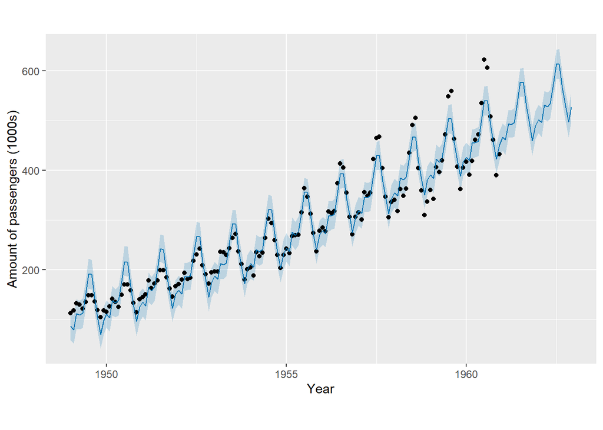

```r
plot(Prophet_Data,Data_Prediction,xlab="Year",ylab="Amount of passengers (1000s)")
```

From our plot, we can clearly see the trend continuing for the next 24 months, in a similar way to that from the previous decade.

We can now go slightly further and project this data up to current day, and compare it to real life results.

## **Projecting To Current Day**

We can use the `make_future_dataframe` instruction once again in order to make a `dataframe` consisting of future predictions up to current day. However for the sake of accessible comparison, we will forecast the data up to the end of 2020, and compare it with real life results.

```r
Further_Future_Data<- make_future_dataframe(Prophet_Data,720, freq="month")
Further_Data_Prediction<- predict(Prophet_Data,Further_Future_Data)
tail(Further_Data_Prediction[c('ds','yhat','yhat_lower','yhat_upper')])
```

```
##             ds     yhat yhat_lower yhat_upper
## 859 2020-07-01 2749.091   2419.656   3031.631
## 860 2020-08-01 2749.985   2413.123   3030.107
## 861 2020-09-01 2700.811   2364.410   2987.157
## 862 2020-10-01 2666.166   2339.508   2961.752
## 863 2020-11-01 2631.305   2293.144   2926.162
## 864 2020-12-01 2660.436   2327.241   2951.002
```

```r
Passengers_In_2020<- sum(tail(Further_Data_Prediction$yhat,12)); Passengers_In_2020*1000
```

```
## [1] 32129131
```

In comparison to actual real-life data, this number is significantly smaller. Despite 2020 being the year where the Covid-19 pandemic took place, according to the International Air Transport Association an estimated 1.8 billion passengers flew in 2020. This alone is a significant difference, without even factoring the variable of the pandemic occurring. This number was around 60% lower than the 4.5 billion passengers who flew in 2019, which once again, is no where near our forecast.

Nonetheless, before we explore the different reasons of why this could be the case, let’s create a `plot` for the `Further_Data_Prediction` data.

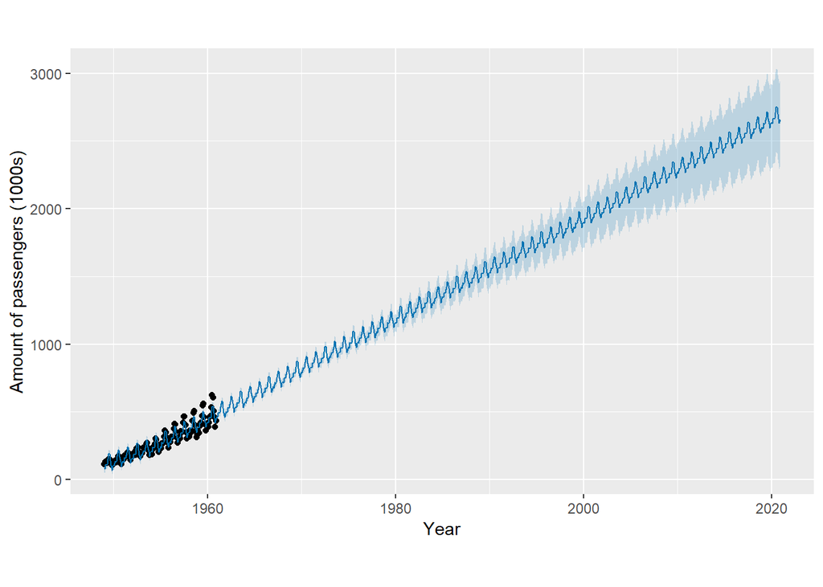

```r
plot(Prophet_Data,Further_Data_Prediction,xlab="Year",ylab="Amount of passengers (1000s)")
```

As we have seen from the results, the forecast created up to 2020 proved to be extremely different to the real life data and information we know. There are many potential reasons why this is the case, including the fact that air transportation has evolved from only really being a luxury for people to enjoy, to an essential part of everyone’s lives. The growth seen in reality resembles more of an exponential growth, rather than a linear one, which is something that our forecast does not consider. Real life changes in supply and demand from over 50 years ago, have a significant impact on the actual results, compared to the predicted ones.

In this project, I have used Meta’s forecasting system `prophet` in order to predict the future amount of air passengers over the next 2 years, using the original `Air Passengers` time series within `R`. I then also took it a step further to see how useful this would be for making a forecast up to current day. The results I found have been very interesting, and I hope that you have found this read to be very informative as well.